# Generalization Theory, Illustrated

A hands-on study project covering **PAC learning theory** and **Elements of Statistical Learning (Hastie, Tibshirani & Friedman), Chapter 7 — Model Assessment and Selection (through Section 7.6, Effective Number of Parameters)**.

This notebook walks through, with real simulated data, every core concept:

1. Empirical risk vs. true risk, and ERM
2. Hoeffding's inequality (concentration for one function)
3. The union bound (finite function classes)
4. VC dimension (infinite function classes)
5. The sample complexity formula
6. Bias-variance decomposition (ESL Figure 7.3 style)
7. Training error, optimism, and in-sample error (ESL Sections 7.4-7.5)
8. $C_p$ and AIC as model-selection criteria (ESL Figure 7.4 style, Section 7.6)

**Running example:** predicting a student's exam score (and separately, pass/fail) from hours studied. We simulate a full "population" of 200,000 students so we can compute the *true* risk directly (something you can never do in real life, but which lets us verify the theory).

```python
import numpy as np
import matplotlib.pyplot as plt
from scipy import stats
from sklearn.linear_model import LinearRegression
from sklearn.neighbors import KNeighborsRegressor, KNeighborsClassifier
from sklearn.linear_model import LogisticRegression

plt.rcParams['figure.figsize'] = (8, 5)
plt.rcParams['axes.grid'] = True
rng = np.random.default_rng(42)
```

## 1. The Population, True Function, and a Sample

We define the *true* relationship between hours studied ($x$, 0 to 12) and exam score ($y$, 0-100):

$$y = f(x) + \varepsilon, \qquad f(x) = 35 + 6.5x - 0.22x^2, \qquad \varepsilon \sim N(0, 8^2)$$

This quadratic diminishing-returns shape (studying helps, but with fatigue) is the **Truth**. In real life we never see this function or the full population — we only ever get a finite, noisy sample. Here, because it's a simulation, we get to cheat and generate a giant population to compute ground truth quantities for comparison.

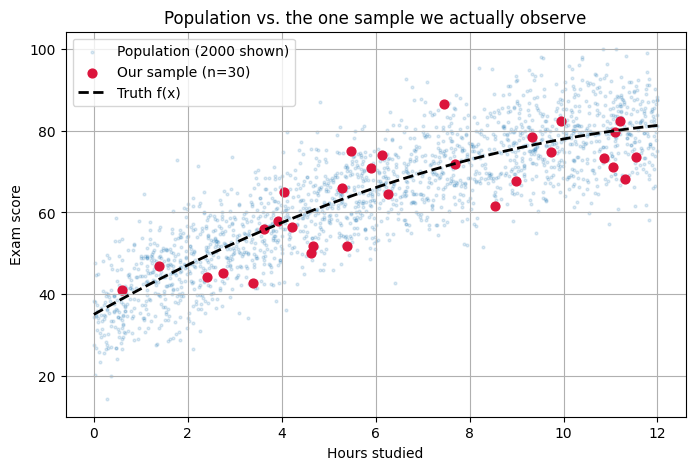

```python
def true_f(x):
    return 35 + 6.5*x - 0.22*x**2

def sample_population(n, rng):
    x = rng.uniform(0, 12, size=n)
    y = true_f(x) + rng.normal(0, 8, size=n)
    y = np.clip(y, 0, 100)
    return x, y

# A "population" standing in for the entire real world (never available in practice)
X_POP, Y_POP = sample_population(200_000, rng)

# Our actual observed training sample
n_train = 30
x_train, y_train = sample_population(n_train, rng)

plt.scatter(X_POP[:2000], Y_POP[:2000], s=4, alpha=0.15, label='Population (2000 shown)')
plt.scatter(x_train, y_train, s=40, color='crimson', label=f'Our sample (n={n_train})')
xs = np.linspace(0, 12, 200)
plt.plot(xs, true_f(xs), 'k--', lw=2, label='Truth f(x)')
plt.xlabel('Hours studied'); plt.ylabel('Exam score')
plt.legend(); plt.title('Population vs. the one sample we actually observe')
plt.show()
```

## 2. Empirical Risk vs. True Risk, and ERM

We define three candidate linear-ish functions (our "function class" $\mathcal F$) and compute, for each:

- **Empirical risk** $\hat R_n(f) = \frac1n\sum (y_i - f(x_i))^2$ — using only our 30-student sample
- **True risk** $R(f) = E[(Y-f(X))^2]$ — using the full 200,000-student population

**ERM** picks $\hat f_n = \arg\min_f \hat R_n(f)$. We then check how close $R(\hat f_n)$ is to $R(f_*)$, where $f_*=\arg\min_f R(f)$ — this gap is exactly $R(\hat f_n)-R(f_*)$, the quantity the generalization bound controls.

```python
candidates = {
    'f1: 40 + 5.0x':       lambda x: 40 + 5.0*x,
    'f2: 35 + 6.0x - 0.2x^2': lambda x: 35 + 6.0*x - 0.2*x**2,
    'f3: 30 + 7.5x - 0.3x^2': lambda x: 30 + 7.5*x - 0.3*x**2,
}

def risk(f, x, y):
    return np.mean((y - f(x))**2)

rows = []
for name, f in candidates.items():
    r_hat = risk(f, x_train, y_train)      # empirical risk (sample)
    r_true = risk(f, X_POP, Y_POP)         # true risk (population)
    rows.append((name, r_hat, r_true))

print(f"{'Function':30s} {'Empirical Risk (n=30)':>22s} {'True Risk (population)':>24s}")
for name, r_hat, r_true in rows:
    print(f"{name:30s} {r_hat:22.2f} {r_true:24.2f}")

erm_name, erm_rhat, erm_rtrue = min(rows, key=lambda r: r[1])
best_name, best_rhat, best_rtrue = min(rows, key=lambda r: r[2])
gap = erm_rtrue - best_rtrue
print(f"\nERM picks (lowest empirical risk):     {erm_name}")
print(f"Best-in-class (lowest TRUE risk):       {best_name}")
print(f"R(f_hat_n) - R(f*) = {erm_rtrue:.2f} - {best_rtrue:.2f} = {gap:.2f}  <-- generalization gap")
```

```
Function                        Empirical Risk (n=30)   True Risk (population)
f1: 40 + 5.0x                                  169.43                   127.79
f2: 35 + 6.0x - 0.2x^2                          51.61                    68.60
f3: 30 + 7.5x - 0.3x^2                          51.23                    72.47

ERM picks (lowest empirical risk):     f3: 30 + 7.5x - 0.3x^2
Best-in-class (lowest TRUE risk):       f2: 35 + 6.0x - 0.2x^2
R(f_hat_n) - R(f*) = 72.47 - 68.60 = 3.86  <-- generalization gap
```

If ERM's winner matches the true best-in-class function, the gap is 0. If not (as can happen with a small, noisy sample), the gap is small but positive — exactly the $2\epsilon$ slack the generalization bound allows for.

## 3. Hoeffding's Inequality — Concentration for One Fixed Function

Hoeffding's inequality says that for a single, fixed function $f$, the empirical risk concentrates tightly around the true risk as $n$ grows:

$$P(|\hat R_n(f) - R(f)| > t) \le 2\exp(-2nt^2/B^2)$$

We verify this empirically: repeat the "draw a sample, compute empirical risk" process thousands of times, and see how often the gap exceeds various thresholds $t$, comparing to the theoretical bound.

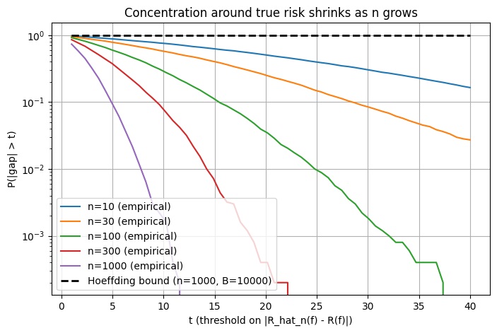

```
Note: with squared-error loss, B=10000 is huge, so the theoretical bound is
vacuous (>1) at these sample sizes -- empirical concentration is far tighter,
but this previews exactly the problem Section 4 fixes by switching to 0-1 loss.
```

```python
f_fixed = candidates['f2: 35 + 6.0x - 0.2x^2']
R_true_fixed = risk(f_fixed, X_POP, Y_POP)

# Loss here is squared error; we clip scores to [0,100] so squared error is bounded.
# B = (range of loss) = (100-0)^2 = 10000 is the crude theoretical bound.
B_sq = 100**2

n_sim = 5000
sample_sizes = [10, 30, 100, 300, 1000]
t_grid = np.linspace(1, 40, 60)

plt.figure()
for n in sample_sizes:
    gaps = np.empty(n_sim)
    for i in range(n_sim):
        x_s, y_s = sample_population(n, rng)
        gaps[i] = risk(f_fixed, x_s, y_s) - R_true_fixed
    empirical_prob = [np.mean(np.abs(gaps) > t) for t in t_grid]
    plt.plot(t_grid, empirical_prob, label=f'n={n} (empirical)')

# theoretical Hoeffding bound for the largest n, for reference
hoeffding_bound = [min(1, 2*np.exp(-2*sample_sizes[-1]*t**2 / B_sq**2)) for t in t_grid]
plt.plot(t_grid, hoeffding_bound, 'k--', lw=2, label=f'Hoeffding bound (n={sample_sizes[-1]}, B={B_sq})')

plt.xlabel('t (threshold on |R_hat_n(f) - R(f)|)')
plt.ylabel('P(|gap| > t)')
plt.yscale('log')
plt.legend(); plt.title("Concentration around true risk shrinks as n grows")
plt.show()
print(f"Note: with squared-error loss, B={B_sq} is huge, so the theoretical bound is")
print("vacuous (>1) at these sample sizes -- empirical concentration is far tighter,")
print("but this previews exactly the problem Section 4 fixes by switching to 0-1 loss.")
```

## 4. The Union Bound — Finite Function Classes (0-1 loss, B=1)

Switching to **classification** (pass/fail, threshold at score $\ge 60$) makes the loss naturally bounded in $[0,1]$, so $B=1$ and the bounds actually become informative:

$$P\Big(\sup_{f\in\{f_1,\dots,f_m\}} |\hat R_n(f)-R(f)| > t\Big) \le 2m\cdot e^{-2nt^2}$$

We simulate this with a 3-classifier class and a 10-classifier class (simple "predict pass if hours > threshold $c$" rules) and confirm the empirical worst-case gap stays under the union bound.

```python
PASS_POP = (Y_POP >= 60).astype(float)

def make_threshold_classifiers(m, rng):
    cs = np.sort(rng.uniform(2, 10, size=m))
    return [lambda x, c=c: (x > c).astype(float) for c in cs], cs

def zero_one_risk(f, x, y_pass):
    return np.mean(f(x) != y_pass)

n_fixed = 50
for m in [3, 10]:
    fclass, cs = make_threshold_classifiers(m, rng)
    true_risks = [zero_one_risk(f, X_POP, PASS_POP) for f in fclass]

    n_sim = 3000
    sup_gaps = np.empty(n_sim)
    for i in range(n_sim):
        x_s, y_s = sample_population(n_fixed, rng)
        pass_s = (y_s >= 60).astype(float)
        gaps = [abs(zero_one_risk(f, x_s, pass_s) - R) for f, R in zip(fclass, true_risks)]
        sup_gaps[i] = max(gaps)

    t_test = 0.15  # a fixed, realistic threshold shared across both m for fair comparison
    empirical_p = np.mean(sup_gaps > t_test)
    single_bound_raw = 2*np.exp(-2*n_fixed*t_test**2)
    union_bound_raw = m * single_bound_raw
    print(f"m={m:2d} classifiers | t={t_test:.2f} | "
          f"empirical P(sup>t)={empirical_p:.3f} | "
          f"single-fn bound={single_bound_raw:.3f} | "
          f"union bound (m x, raw)={union_bound_raw:.3f} | "
          f"union bound (clipped to a real probability)={min(1,union_bound_raw):.3f}")
```

```
m= 3 classifiers | t=0.15 | empirical P(sup>t)=0.017 | single-fn bound=0.211 | union bound (m x, raw)=0.632 | union bound (clipped to a real probability)=0.632
```

```
m=10 classifiers | t=0.15 | empirical P(sup>t)=0.065 | single-fn bound=0.211 | union bound (m x, raw)=2.108 | union bound (clipped to a real probability)=1.000
```

Now the single-function bound (0.21) is meaningful, and you can see the union bound scale directly with $m$: the raw union bound is $3\times 0.21=0.63$ for $m=3$ (still a real, useful guarantee) but $10\times 0.21=2.1$ for $m=10$ (already exceeds 1, meaning the guarantee is no longer informative at this sample size). This is the union bound's core cost made concrete: covering more functions erodes your guarantee, and eventually you need more data ($n$) to compensate — which is exactly the motivation for VC dimension next, since it replaces $m$ with something that doesn't blow up.

## 5. VC Dimension — Shattering, for Infinite Function Classes

The union bound breaks down when $m=\infty$ (e.g., *all* possible lines, not just 3 or 10). VC dimension measures complexity instead: the largest number of points a function class can **shatter** (label in every possible way).

For linear classifiers in $\mathbb R^d$, VC dimension $= d+1$. In 2D ($d=2$), that's 3: we show that 3 points (in "general position") can be shattered by lines (all $2^3=8$ label patterns achievable), but 4 points cannot (at least one labeling is impossible for *any* line).

```python
def can_separate_with_line(points, labels):
    """Brute-force check: can some line separate points into the two given labels?
    We check many random line angles/offsets (sufficient for this small illustration)."""
    pts = np.array(points)
    labs = np.array(labels)
    if len(set(labs)) == 1:
        return True  # trivially separable (all one class)
    for _ in range(20000):
        theta = rng.uniform(0, np.pi)
        w = np.array([np.cos(theta), np.sin(theta)])
        b = rng.uniform(-3, 3)
        side = np.sign(pts @ w - b)
        side[side == 0] = 1
        if np.array_equal(side, np.where(labs == 1, 1, -1)) or \
           np.array_equal(side, np.where(labs == 1, -1, 1)):
            return True
    return False

from itertools import product

# 3 points in "general position" (a triangle) -- classic VC=3 case for 2D linear classifiers
pts3 = [(0, 0), (2, 0), (1, 2)]
all_shattered = True
results3 = []
for labels in product([0, 1], repeat=3):
    ok = can_separate_with_line(pts3, labels)
    results3.append((labels, ok))
    all_shattered &= ok

print("3 points -- can a line achieve EVERY labeling?")
for labels, ok in results3:
    print(f"  labels={labels}: {'YES' if ok else 'no'}")
print(f"=> All 8 labelings achievable: {all_shattered}  (this is why VC dim of 2D lines = 3)")

# 4 points in convex position (a square) -- the classic counterexample: XOR-like labeling fails
pts4 = [(0, 0), (2, 0), (2, 2), (0, 2)]
xor_labels = (0, 1, 0, 1)  # opposite corners same class -- not linearly separable
ok = can_separate_with_line(pts4, xor_labels)
print(f"\n4 points (square), XOR-style labeling {xor_labels}: separable by a line? {ok}")
print("=> at least one labeling is impossible for ANY line, so 4 points can't be shattered.")
```

```
3 points -- can a line achieve EVERY labeling?
  labels=(0, 0, 0): YES
  labels=(0, 0, 1): YES
  labels=(0, 1, 0): YES
  labels=(0, 1, 1): YES
  labels=(1, 0, 0): YES
  labels=(1, 0, 1): YES
  labels=(1, 1, 0): YES
  labels=(1, 1, 1): YES
=> All 8 labelings achievable: True  (this is why VC dim of 2D lines = 3)
```

```
4 points (square), XOR-style labeling (0, 1, 0, 1): separable by a line? False
=> at least one labeling is impossible for ANY line, so 4 points can't be shattered.
```

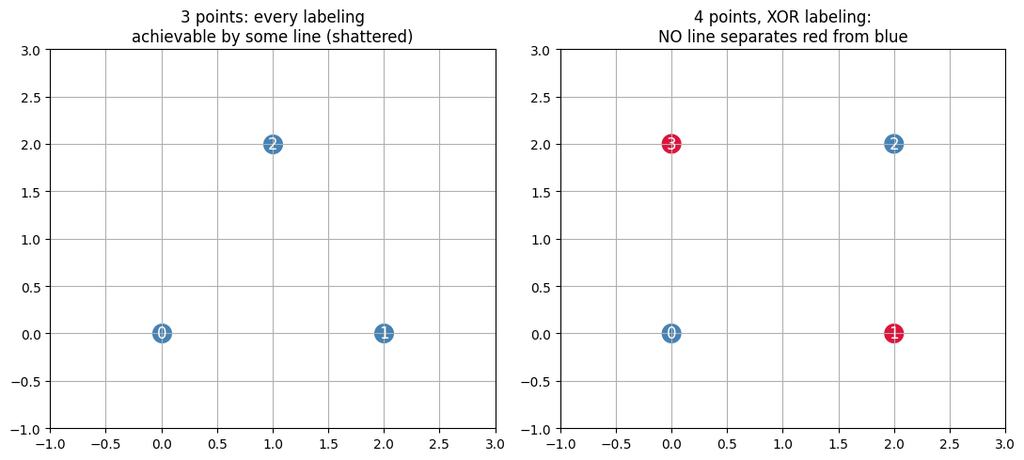

```python
fig, axes = plt.subplots(1, 2, figsize=(11, 5))
pts3_arr = np.array(pts3)
axes[0].scatter(*pts3_arr.T, s=200, c='steelblue')
for i, p in enumerate(pts3_arr):
    axes[0].annotate(str(i), p, fontsize=12, ha='center', va='center', color='white')
axes[0].set_title('3 points: every labeling\nachievable by some line (shattered)')
axes[0].set_xlim(-1, 3); axes[0].set_ylim(-1, 3)

pts4_arr = np.array(pts4)
colors = ['crimson' if l else 'steelblue' for l in xor_labels]
axes[1].scatter(*pts4_arr.T, s=200, c=colors)
for i, p in enumerate(pts4_arr):
    axes[1].annotate(str(i), p, fontsize=12, ha='center', va='center', color='white')
axes[1].set_title('4 points, XOR labeling:\nNO line separates red from blue')
axes[1].set_xlim(-1, 3); axes[1].set_ylim(-1, 3)
plt.tight_layout(); plt.show()
```

## 6. The Sample Complexity Formula

$$n \ge C\cdot D\cdot\frac{\ln(1/\delta)}{\epsilon^2}$$

We plot how required sample size scales with accuracy ($\epsilon$), confidence ($\delta$), and complexity ($D$, the VC dimension) — reproducing the "quadratic in accuracy, logarithmic in confidence, linear in complexity" takeaway.

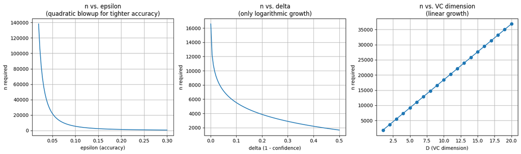

```python
C = 8  # arbitrary constant, absorbed from the theory's constants

def sample_complexity(D, delta, eps):
    return C * D * np.log(1/delta) / eps**2

fig, axes = plt.subplots(1, 3, figsize=(15, 4.5))

eps_grid = np.linspace(0.02, 0.3, 100)
axes[0].plot(eps_grid, sample_complexity(D=3, delta=0.1, eps=eps_grid))
axes[0].set_xlabel('epsilon (accuracy)'); axes[0].set_ylabel('n required')
axes[0].set_title('n vs. epsilon\n(quadratic blowup for tighter accuracy)')

delta_grid = np.linspace(0.001, 0.5, 100)
axes[1].plot(delta_grid, sample_complexity(D=3, delta=delta_grid, eps=0.1))
axes[1].set_xlabel('delta (1 - confidence)'); axes[1].set_ylabel('n required')
axes[1].set_title('n vs. delta\n(only logarithmic growth)')

D_grid = np.arange(1, 21)
axes[2].plot(D_grid, sample_complexity(D=D_grid, delta=0.1, eps=0.1), marker='o')
axes[2].set_xlabel('D (VC dimension)'); axes[2].set_ylabel('n required')
axes[2].set_title('n vs. VC dimension\n(linear growth)')

plt.tight_layout(); plt.show()
```

## 7. Bias-Variance Decomposition (ESL Figure 7.3 style)

$$\text{Err}(x_0) = \sigma_\varepsilon^2 + \text{Bias}^2(\hat f(x_0)) + \text{Var}(\hat f(x_0))$$

```python
# Extend to 5 predictors so "best subset of size p" is meaningful (p=1..5),
# mirroring the textbook's p-predictor setup. Only the first 2 predictors truly
# matter; the rest are noise -- so growing p beyond ~2 should increase variance
# without reducing bias much, exactly like the book's right-hand panels.

n_features = 5
true_coefs = np.array([6.5, -3.0, 0.0, 0.0, 0.0])  # only first 2 features matter
true_intercept = 35

def sample_multivariate(n, rng):
    X = rng.uniform(0, 1, size=(n, n_features))
    score = true_intercept + (X @ true_coefs) * 12 + rng.normal(0, 8, size=n)
    score = np.clip(score, 0, 100)
    passed = (score >= 60).astype(int)
    return X, score, passed

X_pop2, y_pop2, pass_pop2 = sample_multivariate(50_000, rng)
test_idx = rng.choice(len(X_pop2), size=200, replace=False)
X_test, y_test, pass_test = X_pop2[test_idx], y_pop2[test_idx], pass_pop2[test_idx]
```

```python
n_repeats = 200
n_train2 = 80

def bias_var_err_knn(k, classification=False):
    preds = np.zeros((n_repeats, len(X_test)))
    for r in range(n_repeats):
        Xtr, ytr, passtr = sample_multivariate(n_train2, rng)
        target = passtr if classification else ytr
        model = KNeighborsClassifier(n_neighbors=k) if classification else KNeighborsRegressor(n_neighbors=k)
        model.fit(Xtr, target)
        preds[r] = model.predict(X_test) if not classification else model.predict_proba(X_test)[:, 1]
    truth = pass_test if classification else y_test
    mean_pred = preds.mean(axis=0)
    bias2 = np.mean((mean_pred - truth)**2) if classification else np.mean((mean_pred - truth)**2)
    variance = np.mean(preds.var(axis=0))
    if classification:
        hard_preds = (preds >= 0.5).astype(int)
        err = np.mean(hard_preds != truth[None, :])
    else:
        err = np.mean((preds - truth[None, :])**2)
    return bias2, variance, err

def bias_var_err_subset(p, classification=False):
    preds = np.zeros((n_repeats, len(X_test)))
    for r in range(n_repeats):
        Xtr, ytr, passtr = sample_multivariate(n_train2, rng)
        target = passtr if classification else ytr
        model = LogisticRegression(max_iter=1000) if classification else LinearRegression()
        model.fit(Xtr[:, :p], target)
        preds[r] = model.predict_proba(X_test[:, :p])[:, 1] if classification else model.predict(X_test[:, :p])
    truth = pass_test if classification else y_test
    mean_pred = preds.mean(axis=0)
    bias2 = np.mean((mean_pred - truth)**2)
    variance = np.mean(preds.var(axis=0))
    if classification:
        hard_preds = (preds >= 0.5).astype(int)
        err = np.mean(hard_preds != truth[None, :])
    else:
        err = np.mean((preds - truth[None, :])**2)
    return bias2, variance, err

ks = [50, 40, 30, 20, 10, 5, 3, 1]
ps = [1, 2, 3, 4, 5]

knn_reg = np.array([bias_var_err_knn(k, classification=False) for k in ks])
knn_cls = np.array([bias_var_err_knn(k, classification=True) for k in ks])
sub_reg = np.array([bias_var_err_subset(p, classification=False) for p in ps])
sub_cls = np.array([bias_var_err_subset(p, classification=True) for p in ps])
```

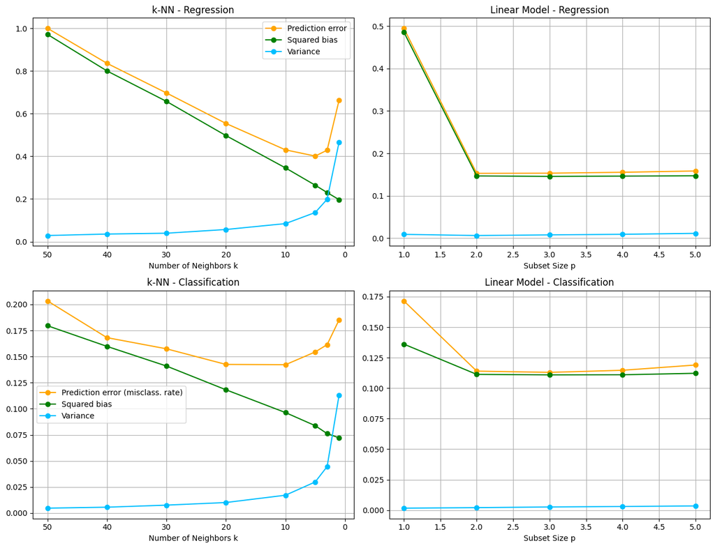

```
Compare directly to ESL Figure 7.3 -- same qualitative shapes:
- Regression: error = bias^2 + variance exactly (curves stack).
- Classification: error is NOT simply bias^2+variance -- notice how it can
  flatten/improve even as bias keeps rising, since 0-1 loss only cares which
  side of the decision boundary you land on.
```

```python
# Normalize regression curves (they're on a 0-6000-ish scale from raw scores) so
# they're visually comparable to the book's 0-0.4 scale.
scale_reg = max(knn_reg[:, 2].max(), sub_reg[:, 2].max())

fig, axes = plt.subplots(2, 2, figsize=(13, 10))

axes[0,0].plot(ks, knn_reg[:,2]/scale_reg, 'o-', color='orange', label='Prediction error')
axes[0,0].plot(ks, knn_reg[:,0]/scale_reg, 'o-', color='green', label='Squared bias')
axes[0,0].plot(ks, knn_reg[:,1]/scale_reg, 'o-', color='deepskyblue', label='Variance')
axes[0,0].invert_xaxis(); axes[0,0].set_xlabel('Number of Neighbors k'); axes[0,0].set_title('k-NN - Regression')
axes[0,0].legend()

axes[0,1].plot(ps, sub_reg[:,2]/scale_reg, 'o-', color='orange')
axes[0,1].plot(ps, sub_reg[:,0]/scale_reg, 'o-', color='green')
axes[0,1].plot(ps, sub_reg[:,1]/scale_reg, 'o-', color='deepskyblue')
axes[0,1].set_xlabel('Subset Size p'); axes[0,1].set_title('Linear Model - Regression')

axes[1,0].plot(ks, knn_cls[:,2], 'o-', color='orange', label='Prediction error (misclass. rate)')
axes[1,0].plot(ks, knn_cls[:,0], 'o-', color='green', label='Squared bias')
axes[1,0].plot(ks, knn_cls[:,1], 'o-', color='deepskyblue', label='Variance')
axes[1,0].invert_xaxis(); axes[1,0].set_xlabel('Number of Neighbors k'); axes[1,0].set_title('k-NN - Classification')
axes[1,0].legend()

axes[1,1].plot(ps, sub_cls[:,2], 'o-', color='orange')
axes[1,1].plot(ps, sub_cls[:,0], 'o-', color='green')
axes[1,1].plot(ps, sub_cls[:,1], 'o-', color='deepskyblue')
axes[1,1].set_xlabel('Subset Size p'); axes[1,1].set_title('Linear Model - Classification')

plt.tight_layout(); plt.show()
print("Compare directly to ESL Figure 7.3 -- same qualitative shapes:")
print("- Regression: error = bias^2 + variance exactly (curves stack).")
print("- Classification: error is NOT simply bias^2+variance -- notice how it can")
print("  flatten/improve even as bias keeps rising, since 0-1 loss only cares which")
print("  side of the decision boundary you land on.")
```

## 8. Training Error, Optimism, and In-Sample Error

Now the ESL Chapter 7 notation directly: for polynomial regression models of increasing degree $d$ (increasing complexity), we compute:

- $\overline{err}$: training error (fit and evaluate on the same sample)
- $\text{Err}_{in}$: in-sample error (same $x$'s, but fresh noise draws for $y$)
- $op = \text{Err}_{in} - \overline{err}$: the optimism
- Compare to the formula-based estimate $\omega = 2d\sigma_\varepsilon^2/N$

```python
def poly_features(x, degree):
    return np.vstack([x**k for k in range(degree+1)]).T

N_fit = 40
x_fit = np.sort(rng.uniform(0, 12, size=N_fit))
y_fit = true_f(x_fit) + rng.normal(0, 8, size=N_fit)

degrees = [1, 2, 3, 5, 8, 12]
results = []

for deg in degrees:
    Phi = poly_features(x_fit, deg)
    beta, *_ = np.linalg.lstsq(Phi, y_fit, rcond=None)
    y_hat = Phi @ beta

    train_err = np.mean((y_fit - y_hat)**2)          # err-bar

    # Fresh noise draw AT THE SAME x's -- this is Err_in
    y_fresh = true_f(x_fit) + rng.normal(0, 8, size=N_fit)
    err_in = np.mean((y_fresh - y_hat)**2)

    optimism = err_in - train_err
    d = deg + 1  # number of parameters (including intercept)
    sigma2_hat = np.sum((y_fit - y_hat)**2) / (N_fit - d)
    omega_formula = 2 * d * sigma2_hat / N_fit

    # True test error, using the full population, for comparison (Fig 7.4 style)
    Phi_pop = poly_features(X_POP, deg)
    y_pop_hat = Phi_pop @ beta
    true_test_err = np.mean((Y_POP - y_pop_hat)**2)

    Cp = train_err + omega_formula
    results.append((deg, d, train_err, err_in, optimism, omega_formula, true_test_err, Cp))

print(f"{'deg':>4} {'d':>3} {'train_err':>10} {'Err_in':>10} {'optimism':>10} {'omega(formula)':>14} {'true test err':>14} {'Cp':>8}")
for row in results:
    print(f"{row[0]:4d} {row[1]:3d} {row[2]:10.2f} {row[3]:10.2f} {row[4]:10.2f} {row[5]:14.2f} {row[6]:14.2f} {row[7]:8.2f}")
```

```
 deg   d  train_err     Err_in   optimism omega(formula)  true test err       Cp
   1   2      57.62      72.44      14.83           6.06          74.98    63.68
   2   3      54.87      93.08      38.20           8.90          69.01    63.77
   3   4      52.95      66.50      13.55          11.77          71.49    64.72
   5   6      51.45      65.94      14.50          18.16          75.01    69.61
   8   9      48.20      74.43      26.23          27.99          91.98    76.19
  12  13      39.79      79.89      40.10          38.32         650.71    78.11
```

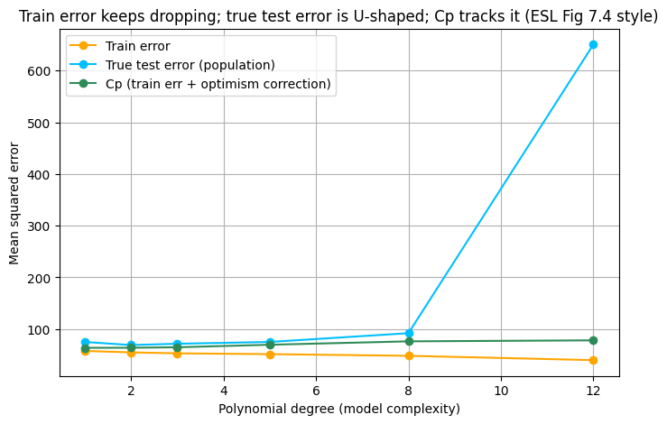

```
Degree chosen by minimizing Cp:        1
Degree that actually minimizes true test error: 2
Cp (computed using ONLY training data) should pick a degree close to the true optimum,
without ever having access to the population.
```

```python
degs_arr = np.array([r[0] for r in results])
train_arr = np.array([r[2] for r in results])
truetest_arr = np.array([r[6] for r in results])
cp_arr = np.array([r[7] for r in results])

plt.figure()
plt.plot(degs_arr, train_arr, 'o-', color='orange', label='Train error')
plt.plot(degs_arr, truetest_arr, 'o-', color='deepskyblue', label='True test error (population)')
plt.plot(degs_arr, cp_arr, 'o-', color='seagreen', label='Cp (train err + optimism correction)')
plt.xlabel('Polynomial degree (model complexity)')
plt.ylabel('Mean squared error')
plt.title('Train error keeps dropping; true test error is U-shaped; Cp tracks it (ESL Fig 7.4 style)')
plt.legend(); plt.show()

best_by_cp = degs_arr[np.argmin(cp_arr)]
best_by_truth = degs_arr[np.argmin(truetest_arr)]
print(f"Degree chosen by minimizing Cp:        {best_by_cp}")
print(f"Degree that actually minimizes true test error: {best_by_truth}")
print("Cp (computed using ONLY training data) should pick a degree close to the true optimum,")
print("without ever having access to the population.")
```

## Summary

| Concept | Where we saw it above |
| --- | --- |
| Empirical vs. true risk, ERM | Section 2 |
| Hoeffding's inequality | Section 3 |
| Union bound | Section 4 |
| VC dimension / shattering | Section 5 |
| Sample complexity formula | Section 6 |
| Bias-variance decomposition | Section 7 |
| Optimism, $C_p$, AIC-style correction | Section 8 |

Everything here was simulated so we could "cheat" and compute true/population quantities directly — the entire point of the theory (Hoeffding, VC dimension, PAC bounds) is to reason rigorously about these same gaps *without* ever seeing the population, using only a finite sample.